# Logistic Regression

## Hello World

This is the **Hello World** program of Machine Learning and it is probably the most simplest machine learning program that you can learn.

### Getting the Dataset

The IRIS Dataset comes pre packages along with the the Scikit Learn library. There are several datasets that come along with the Scikit library. You can see the list of all the datasets here http://scikit-learn.org/stable/datasets/index.html#toy-datasets.

The datatype of the dataset that comes preloaded with Sikit Learn is called as a **Bunch**

### Loading the Dataset

```python
from sklearn import linear_model,datasets
from sklearn.model_selection import train_test_split
from sklearn.metrics import confusion_matrix
import numpy as np
import matplotlib.pyplot as plt
import itertools

iris = datasets.load_iris()

type(iris)
```

```
sklearn.utils.Bunch
```

As explained the type of the dataset object is Bunch. Let us see what is inside a Bunch

```python
iris.keys()
```

```
dict_keys(['data', 'target', 'target_names', 'DESCR', 'feature_names'])
```

Our iris bunch contains 5 values, lets see each one of them separately

#### iris.data

This contains the features of the iris dataset as an numpy array.

```python
print(type(iris.data))
iris.data[:5,:]
```

```
<class 'numpy.ndarray'>
```

```
array([[5.1, 3.5, 1.4, 0.2],
       [4.9, 3. , 1.4, 0.2],
       [4.7, 3.2, 1.3, 0.2],
       [4.6, 3.1, 1.5, 0.2],
       [5. , 3.6, 1.4, 0.2]])
```

#### iris.feature_names

This contains the feature names as a list of the data that we can get from iris.data

```python
print(type(iris.feature_names))
iris.feature_names
```

```
<class 'list'>
```

```
['sepal length (cm)',
 'sepal width (cm)',
 'petal length (cm)',
 'petal width (cm)']
```

#### iris.target

This contains the target value that we are interested in as a ndarray

```python
print(type(iris.target))
iris.target[:5]
```

```
<class 'numpy.ndarray'>
```

```
array([0, 0, 0, 0, 0])
```

#### iris.target_names

This contains the exact values that the values in the feature nd array corresponds to as a list. From the values we can see that a 0 value in the fatures nd array corresponds to the class **setosa** and a value of 1 in the feature nd array corresponds to the class **versicolor**

```python
print(type(iris.target_names))
iris.target_names
```

```
<class 'numpy.ndarray'>
```

```
array(['setosa', 'versicolor', 'virginica'], dtype='<U10')
```

#### iris.DESCR

This contains the description of the data which we are not already very clear about so the output is not displayed here.

### Splitting Train and Test data

It is always a best practice to split the data into train and test sets so we can compute the performance of our model.

```python
X_train,X_test,y_train,y_test = train_test_split(iris.data,iris.target,test_size=0.30,random_state=7)
```

### Creating a Logistic Regression Model

The base Logistic Regression does not require any parameters, so just creating an object with the LogisticRegression constructor is sufficient.

```python
log_reg_model = linear_model.LogisticRegression()
```

### Fitting the training data to the model

```python
log_reg_model.fit(X_train,y_train)
```

```
LogisticRegression(C=1.0, class_weight=None, dual=False, fit_intercept=True,
          intercept_scaling=1, max_iter=100, multi_class='ovr', n_jobs=1,
          penalty='l2', random_state=None, solver='liblinear', tol=0.0001,
          verbose=0, warm_start=False)
```

### Measuring the performance of the model

#### Accuracy

The model has been trained but we need to measure the performance of the model. For all the linear classification models, Sklearn library uses the mean accuracy to measure the model performance.

```python
log_reg_base_score = log_reg_model.score(X_test,y_test)
print("The score for the Logistic Regression Model is : ", log_reg_base_score)
```

```
The score for the Logistic Regression Model is :  0.8888888888888888
```

Great the model is performing at **88%** accuracy which is not bad for the size of the dataset.

#### Confusion Matrix

Another basic metric is the confusion matrix which gives us the exact True Positive, True Negative, False Positive and False Nagative values based on which the Accuracy is computed

```python
cm = confusion_matrix(y_test,log_reg_model.predict(X_test))
print(cm)
```

```
[[12  0  0]
 [ 0 12  4]
 [ 0  1 16]]
```

The values along the y-axis are the true labels and the values along the x-axis are the Predicted labels. The diagonal elements represent the number of points for which the predicted label is equal to the true label, while off-diagonal elements are those that are mislabeled by the classifier.

### Visualising the Dataset

http://scikit-learn.org/stable/auto_examples/linear_model/plot_iris_logistic.html#logistic-regression-3-class-classifier

Now that we have created a Machine Learning model and also measured it's performance we can go ahead and visualise the dataset and our prediction so we better understand what we did.

Our dataset is a 4 Dimensional dataset and it is very difficult to visualise in 4 dimensiona and even if we manage to visualise a 4 Dimensional data it would "Not seem like anything to our human brain" so we just take 2 datapoint from the dataset so we can understand our visualisation.

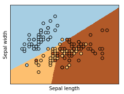

```python
X = iris.data[:,:2]
Y = iris.target

log_reg_model.fit(X,y)

# Plot the decision boundary. For that, we will assign a color to each
# point in the mesh [x_min, x_max]x[y_min, y_max].
x_min, x_max = X[:, 0].min() - .5, X[:, 0].max() + .5
y_min, y_max = X[:, 1].min() - .5, X[:, 1].max() + .5

xx, yy = np.meshgrid(np.arange(x_min, x_max, .01), np.arange(y_min, y_max, .01))

Z = log_reg_model.predict(np.c_[xx.ravel(), yy.ravel()])

Z = Z.reshape(xx.shape)
plt.figure(1, figsize=(4, 3))
plt.pcolormesh(xx, yy, Z, cmap=plt.cm.Paired)

# Plot also the training points
plt.scatter(X[:, 0], X[:, 1], c=Y, edgecolors='k', cmap=plt.cm.Paired)
plt.xlabel('Sepal length')
plt.ylabel('Sepal width')

plt.xlim(xx.min(), xx.max())
plt.ylim(yy.min(), yy.max())
plt.xticks(())
plt.yticks(())

plt.show()
```

### Visualising the Confusion Matrix

http://scikit-learn.org/stable/auto_examples/model_selection/plot_confusion_matrix.html#sphx-glr-auto-examples-model-selection-plot-confusion-matrix-py

The confusion matrix that we created above can also be visualised for easier understanding.

```python
def plot_confusion_matrix(cm, classes,
                          normalize=False,
                          title='Confusion matrix',
                          cmap=plt.cm.Blues):
    """
    This function prints and plots the confusion matrix.
    Normalization can be applied by setting `normalize=True`.
    """
    if normalize:
        cm = cm.astype('float') / cm.sum(axis=1)[:, np.newaxis]
        print("Normalized confusion matrix")
    else:
        print('Confusion matrix, without normalization')

    print(cm)

    plt.imshow(cm, interpolation='nearest', cmap=cmap)
    plt.title(title)
    plt.colorbar()
    tick_marks = np.arange(len(classes))
    plt.xticks(tick_marks, classes, rotation=45)
    plt.yticks(tick_marks, classes)

    fmt = '.2f' if normalize else 'd'
    thresh = cm.max() / 2.
    for i, j in itertools.product(range(cm.shape[0]), range(cm.shape[1])):
        plt.text(j, i, format(cm[i, j], fmt),
                 horizontalalignment="center",
                 color="white" if cm[i, j] > thresh else "black")

    plt.tight_layout()
    plt.ylabel('True label')
    plt.xlabel('Predicted label')
```

```
Confusion matrix, without normalization
[[12  0  0]
 [ 0 12  4]
 [ 0  1 16]]
```

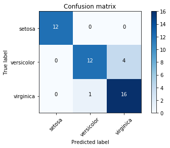

```python
# Compute confusion matrix
log_reg_model.fit(X_train,y_train)
cnf_matrix = confusion_matrix(y_test, log_reg_model.predict(X_test))
np.set_printoptions(precision=2)

plt.figure()
plot_confusion_matrix(cnf_matrix, classes=iris.target_names,
                      title='Confusion matrix')
```